# Homework 1

Michelle Jen

9/18/2019

```r
library(tidyverse)
```

# Problem 1

## code chunk 1

Create a data frame comprised of:

- a random sample of size 8 from a standard Normal distribution
- a logical vector indicating whether elements of the sample are greater than 0
- a character vector of length 8
- a factor vector of length 8, with 3 different factor “levels”

```r
one_df = tibble(
  sample = rnorm(8),
  vec_logical = sample > 0,
  vec_character = c('a','b','c','d','e','f','g','h'),
  vec_factor = factor(c("big","med","small","big","med","small","big","small"))
)
```

Try to take the mean of each variable in your dataframe. What works and what doesn’t?

```r
mean(pull(one_df, sample))
```

```
## [1] 0.4392061
```

```r
mean(pull(one_df, vec_logical))
```

```
## [1] 0.625
```

```r
mean(pull(one_df, vec_character))
```

```
## [1] NA
```

```r
mean(pull(one_df,vec_factor))
```

```
## [1] NA
```

It works to take the mean of a random sample and a logical vector. However, it doesn’t work to take a mean of a character vector or a factor vector since they’re not numeric or logical.

## code chunk 2

In a second code chunk:

- convert the logical vector to numeric, and multiply the random sample by the result
- convert the logical vector to a factor, and multiply the random sample by the result
- convert the logical vector to a factor and then convert the result to numeric, and multiply the random sample by the result

```r
log_num = as.numeric(pull(one_df,vec_logical))
product_num = log_num*pull(one_df, sample)

log_fact = as.factor(pull(one_df, vec_logical))
product_fact = log_fact*pull(one_df, sample) # ‘*’ not meaningful for factors. This makes sense since the factor vector did not yield a mean.#
fact_num = as.numeric(log_fact)
product_num_random = fact_num*pull(one_df, sample)
```

# Problem 2

Create a data frame comprised of:

- x: a random sample of size 500 from a standard Normal distribution
- y: a random sample of size 500 from a standard Normal distribution
- A logical vector indicating whether x + y > 1
- A numeric vector created by coercing the above logical vector
- A factor vector created by coercing the above logical vector

```r
two_df = tibble(
  x = rnorm(500),
  y = rnorm(500),
  log_vector = x + y > 1,
  num_vector = as.numeric(log_vector),
  fact_vector = as.factor(log_vector),
)
```

```r
nrow(two_df) # The nrow = 500. #
```

```
## [1] 500
```

```r
ncol(two_df) # The ncol = 5. #
```

```
## [1] 5
```

```r
mean(pull(two_df, x))
```

```
## [1] -0.03394438
```

```r
median(pull(two_df, x))
```

```
## [1] -0.01609125
```

```r
sd(pull(two_df, x))
```

```
## [1] 1.015177
```

Make a scatterplot of y vs x; color points using the logical variable (adding color = … inside of aes in your ggplot code should help). Make a second and third scatterplot that color points using the numeric and factor variables, respectively, and comment on the color scales.

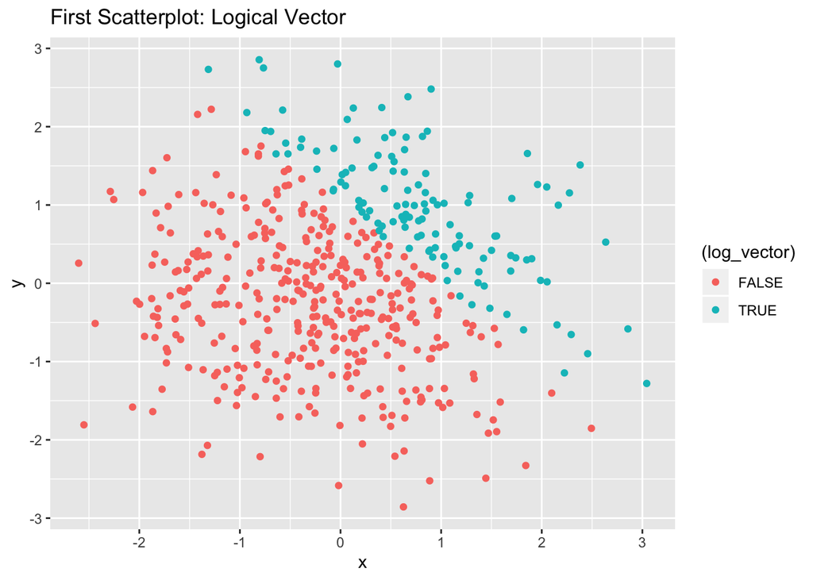

```r
scatterplot_one = ggplot(two_df, aes (x=x, y=y, color = (log_vector))) + geom_point()
print(scatterplot_one + ggtitle("First Scatterplot: Logical Vector")) # The red represents when the logical vector is false, that is x + y =< 1. The blue represents when the logical vector is true, that is x + y > 1. #
```

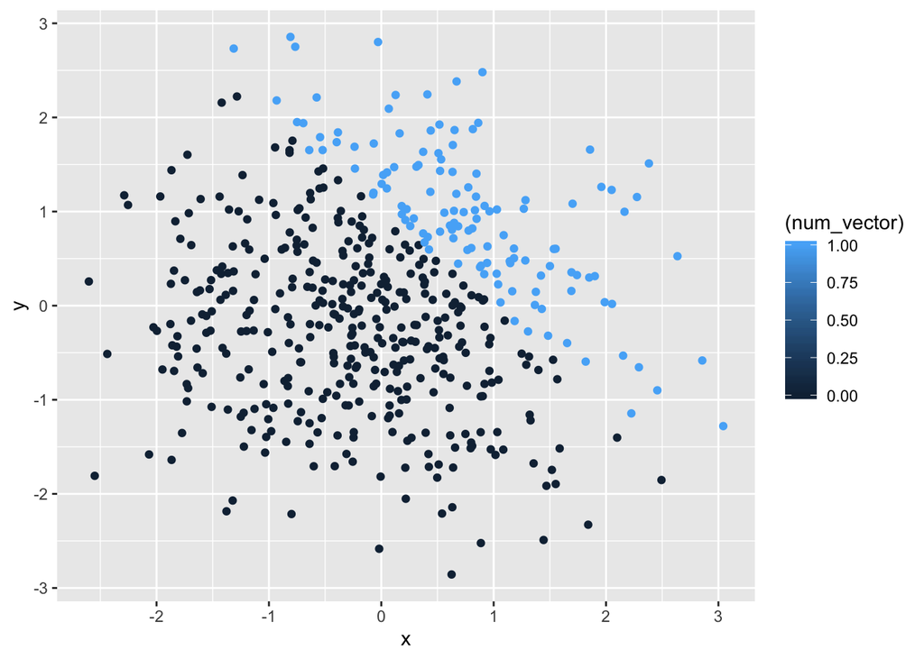

```r
ggplot(two_df, aes (x=x, y=y, color = (num_vector))) + geom_point() # The darker blue represents when the numeric vector is false, that is x + y =<. The lighter blue represents when the numeric factor is true, that is x + y > 1.#
```

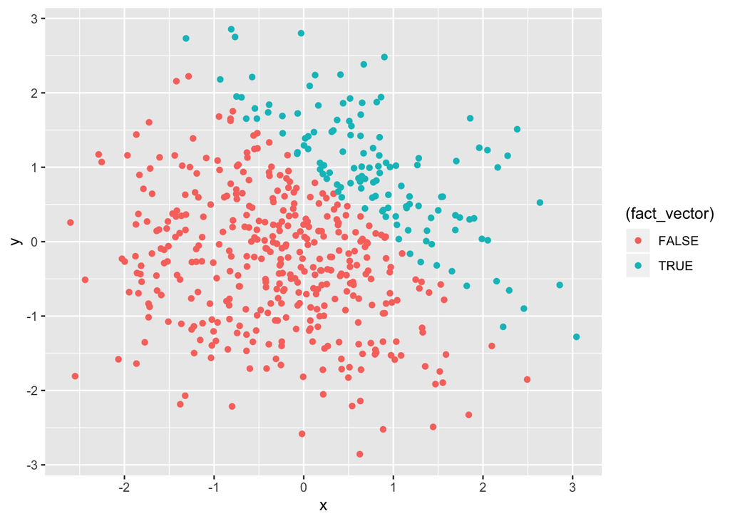

```r
ggplot(two_df, aes (x=x, y=y, color = (fact_vector))) + geom_point() # The red represents when the factor vector is false, that is x + y =< 1. The blue represents when the factor vector is true, that is x + y > 1. #
```

```r
ggsave("scatterplot_one.pdf")
```